# Business-friendly countries in Asia and factor analysis

- Introduction
- Data Wrangling
- Exploratory Data Analysis
- Conclusions

## 1. Introduction

The purpose of this analysis is to find the top business environments in Asia, and to quickly test if some factors are related to the excellence in environment.

The multiple dataset are derived from [gapminder.org](http://www.gapminder.org/data/,), and will firstly be used to assess data.

- new business density (new registration per 1000 people, age 15 - 64)
- ease of doing business index (1 = most business friendly regulations)
- cost of business start-up procedure (% GNI per capita)
- time required to start a business (days)
- foreign direct investments inflows (net % of GDP)
- income per person (GDP / capita, PPP$ inflation-adjusted)
- population density per squired km
- life expectancy in years

### `1-1.` Import & inspect each dataset

```python
# Use this cell to set up import statements for all of the packages that you
import pandas as pd
import numpy as np
```

#### Please understand that he below dataset is removed from the directory, and merged into a `env_analysis_v1.csv` file relative link here

```python
bus_regi = pd.read_csv('new_bus_density.csv') # new business registration
bus_ease = pd.read_csv('bus_ease.csv')
cost_startup = pd.read_csv('cost_startup.csv')
time_startup = pd.read_csv('time_startup.csv')
foreign_investment = pd.read_csv('foreign_investment.csv')
income = pd.read_csv('income.csv')
life_exp = pd.read_csv('life_expectancy.csv')
pop_density = pd.read_csv('population_density.csv')
```

```python
bus_regi.head(3) # 2006 - 2018
```

|  | country | 2006 | 2007 | 2008 | 2009 | 2010 | 2011 | 2012 | 2013 | 2014 | 2015 | 2016 | 2017 | 2018 |
| --- | --- | --- | --- | --- | --- | --- | --- | --- | --- | --- | --- | --- | --- | --- |
| 0 | Afghanistan | NaN | NaN | 0.0464 | 0.260 | 0.329 | 0.249 | 0.226 | 0.193 | 0.142 | 0.124 | 0.130 | 0.155 | 0.212 |
| 1 | Albania | 0.723 | 1.110 | 1.5400 | 1.050 | 1.070 | 0.943 | 0.956 | 1.070 | 1.120 | 1.320 | 1.360 | 1.510 | 1.520 |
| 2 | Algeria | 0.189 | 0.159 | 0.1990 | 0.192 | 0.170 | 0.192 | 0.309 | 0.304 | 0.328 | 0.311 | 0.336 | 0.372 | 0.353 |

```python
bus_regi.info() # may missing values but keep for now # dtype is okay
```

```
<class 'pandas.core.frame.DataFrame'>
RangeIndex: 151 entries, 0 to 150
Data columns (total 14 columns):
 #   Column   Non-Null Count  Dtype
---  ------   --------------  -----
 0   country  151 non-null    object
 1   2006     106 non-null    float64
 2   2007     108 non-null    float64
 3   2008     115 non-null    float64
 4   2009     118 non-null    float64
 5   2010     119 non-null    float64
 6   2011     123 non-null    float64
 7   2012     125 non-null    float64
 8   2013     127 non-null    float64
 9   2014     130 non-null    float64
 10  2015     133 non-null    float64
 11  2016     137 non-null    float64
 12  2017     130 non-null    float64
 13  2018     133 non-null    float64
dtypes: float64(13), object(1)
memory usage: 16.6+ KB
```

```python
bus_regi.duplicated(subset = ['country']).sum() # no duplicates
```

```
0
```

```python
bus_ease.head(3)
```

|  | country | 2019 |
| --- | --- | --- |
| 0 | Afghanistan | 173 |
| 1 | Albania | 82 |
| 2 | Algeria | 157 |

```python
bus_ease.info() #only 2019 data available
```

```
<class 'pandas.core.frame.DataFrame'>
RangeIndex: 186 entries, 0 to 185
Data columns (total 2 columns):
 #   Column   Non-Null Count  Dtype
---  ------   --------------  -----
 0   country  186 non-null    object
 1   2019     186 non-null    int64
dtypes: int64(1), object(1)
memory usage: 3.0+ KB
```

```python
bus_ease.duplicated().sum() #no duplicates
```

```
0
```

```python
cost_startup.head(3)
```

|  | country | 2003 | 2004 | 2005 | 2006 | 2007 | 2008 | 2009 | 2010 | 2011 | 2012 | 2013 | 2014 | 2015 | 2016 | 2017 | 2018 | 2019 |
| --- | --- | --- | --- | --- | --- | --- | --- | --- | --- | --- | --- | --- | --- | --- | --- | --- | --- | --- |
| 0 | Afghanistan | 0.0 | 0.0 | 0.0 | 0.0 | 0.0 | 0.0 | 0.0 | 0.0 | 0.0 | 0.0 | 0.0 | 0.0 | 0.0 | 0.0 | 0.0 | 0.0 | 0.0 |
| 1 | Albania | 45.3 | 41.3 | 39.9 | 36.7 | 34.3 | 0.0 | 0.0 | 0.0 | 0.0 | 0.0 | 0.0 | 0.0 | 0.0 | 0.0 | 0.0 | 0.0 | 0.0 |
| 2 | Algeria | 73.2 | 65.5 | 55.1 | 46.0 | 45.2 | 36.6 | 31.0 | 34.4 | 30.6 | 27.2 | 28.6 | 24.1 | 23.6 | 0.0 | 0.0 | 0.0 | 0.0 |

```python
cost_startup.info() # cost of 0.0 does not make sense assumed to be missing values
                    # dtype ok # 2003 - 2019
```

```
<class 'pandas.core.frame.DataFrame'>
RangeIndex: 187 entries, 0 to 186
Data columns (total 18 columns):
 #   Column   Non-Null Count  Dtype
---  ------   --------------  -----
 0   country  187 non-null    object
 1   2003     186 non-null    float64
 2   2004     186 non-null    float64
 3   2005     186 non-null    float64
 4   2006     186 non-null    float64
 5   2007     186 non-null    float64
 6   2008     186 non-null    float64
 7   2009     186 non-null    float64
 8   2010     186 non-null    float64
 9   2011     186 non-null    float64
 10  2012     186 non-null    float64
 11  2013     186 non-null    float64
 12  2014     186 non-null    float64
 13  2015     186 non-null    float64
 14  2016     186 non-null    float64
 15  2017     186 non-null    float64
 16  2018     187 non-null    float64
 17  2019     187 non-null    float64
dtypes: float64(17), object(1)
memory usage: 26.4+ KB
```

```python
cost_startup.duplicated(subset = ['country']).sum() # no duplicates
```

```
0
```

```python
time_startup.head(3)
```

|  | country | 2003 | 2004 | 2005 | 2006 | 2007 | 2008 | 2009 | 2010 | 2011 | 2012 | 2013 | 2014 | 2015 | 2016 | 2017 | 2018 | 2019 |
| --- | --- | --- | --- | --- | --- | --- | --- | --- | --- | --- | --- | --- | --- | --- | --- | --- | --- | --- |
| 0 | Afghanistan | NaN | 9.5 | 9.5 | 9.5 | 10.5 | 10.5 | 9.5 | 9.5 | 9.5 | 9.5 | 6.5 | 8.5 | 8.5 | 8.5 | 8.5 | 8.5 | 8.5 |
| 1 | Albania | 41.0 | 40.0 | 41.0 | 39.0 | 37.0 | 10.0 | 6.0 | 6.0 | 6.0 | 5.0 | 5.0 | 5.0 | 5.0 | 5.0 | 5.0 | 4.5 | 4.5 |
| 2 | Algeria | 25.0 | 24.0 | 22.0 | 22.0 | 22.0 | 22.0 | 22.0 | 22.0 | 22.0 | 22.0 | 22.0 | 20.0 | 18.0 | 18.0 | 18.0 | 18.0 | 18.0 |

```python
time_startup.info() # recent year data seems fine, dtype ok #2003 - 2019
```

```
<class 'pandas.core.frame.DataFrame'>
RangeIndex: 187 entries, 0 to 186
Data columns (total 18 columns):
 #   Column   Non-Null Count  Dtype
---  ------   --------------  -----
 0   country  187 non-null    object
 1   2003     131 non-null    float64
 2   2004     141 non-null    float64
 3   2005     160 non-null    float64
 4   2006     164 non-null    float64
 5   2007     167 non-null    float64
 6   2008     168 non-null    float64
 7   2009     168 non-null    float64
 8   2010     168 non-null    float64
 9   2011     170 non-null    float64
 10  2012     174 non-null    float64
 11  2013     185 non-null    float64
 12  2014     185 non-null    float64
 13  2015     186 non-null    float64
 14  2016     186 non-null    float64
 15  2017     186 non-null    float64
 16  2018     187 non-null    float64
 17  2019     187 non-null    float64
dtypes: float64(17), object(1)
memory usage: 26.4+ KB
```

```python
time_startup.duplicated(subset=['country']).sum() #no duplicates
```

```
0
```

```python
foreign_investment.head(3)
```

|  | country | 1970 | 1971 | 1972 | 1973 | 1974 | 1975 | 1976 | 1977 | 1978 | ... | 2009 | 2010 | 2011 | 2012 | 2013 | 2014 | 2015 | 2016 | 2017 | 2018 |
| --- | --- | --- | --- | --- | --- | --- | --- | --- | --- | --- | --- | --- | --- | --- | --- | --- | --- | --- | --- | --- | --- |
| 0 | Afghanistan | 0.000132 | 0.000246 | 0.000094 | 0.000156 | NaN | NaN | 0.000016 | -0.000081 | NaN | ... | 0.00451 | 0.0120 | 0.00293 | 0.00284 | 0.00235 | 0.00210 | 0.00850 | 0.00483 | 0.00255 | 0.00617 |
| 1 | Albania | NaN | NaN | NaN | NaN | NaN | NaN | NaN | NaN | NaN | ... | 0.11200 | 0.0914 | 0.08140 | 0.07450 | 0.09820 | 0.08690 | 0.08690 | 0.08800 | 0.07850 | 0.07970 |
| 2 | Algeria | 0.016500 | 0.000118 | 0.006140 | 0.005850 | 0.0271 | 0.00765 | 0.010500 | 0.008510 | 0.00513 | ... | 0.02000 | 0.0143 | 0.01290 | 0.00718 | 0.00807 | 0.00703 | -0.00324 | 0.01020 | 0.00717 | 0.00867 |

3 rows × 50 columns

```python
foreign_investment.info() # some missing values # dtype ok # 1970 - 2018
```

```
<class 'pandas.core.frame.DataFrame'>
RangeIndex: 190 entries, 0 to 189
Data columns (total 50 columns):
 #   Column   Non-Null Count  Dtype
---  ------   --------------  -----
 0   country  190 non-null    object
 1   1970     101 non-null    float64
 2   1971     101 non-null    float64
 3   1972     107 non-null    float64
 4   1973     107 non-null    float64
 5   1974     108 non-null    float64
 6   1975     111 non-null    float64
 7   1976     113 non-null    float64
 8   1977     119 non-null    float64
 9   1978     119 non-null    float64
```

[output cut: 42 more lines]

```python
foreign_investment.duplicated(subset = ['country']).sum() #no duplicates
```

```
0
```

```python
income.head(3)
```

|  | country | 1800 | 1801 | 1802 | 1803 | 1804 | 1805 | 1806 | 1807 | 1808 | ... | 2031 | 2032 | 2033 | 2034 | 2035 | 2036 | 2037 | 2038 | 2039 | 2040 |
| --- | --- | --- | --- | --- | --- | --- | --- | --- | --- | --- | --- | --- | --- | --- | --- | --- | --- | --- | --- | --- | --- |
| 0 | Afghanistan | 603 | 603 | 603 | 603 | 603 | 603 | 603 | 603 | 603 | ... | 2550 | 2600 | 2660 | 2710 | 2770 | 2820 | 2880 | 2940 | 3000 | 3060 |
| 1 | Albania | 667 | 667 | 667 | 667 | 667 | 668 | 668 | 668 | 668 | ... | 19400 | 19800 | 20200 | 20600 | 21000 | 21500 | 21900 | 22300 | 22800 | 23300 |
| 2 | Algeria | 715 | 716 | 717 | 718 | 719 | 720 | 721 | 722 | 723 | ... | 14300 | 14600 | 14900 | 15200 | 15500 | 15800 | 16100 | 16500 | 16800 | 17100 |

3 rows × 242 columns

```python
income.info() # massive data from 1800 - 2040 (projection)
```

```
<class 'pandas.core.frame.DataFrame'>
RangeIndex: 193 entries, 0 to 192
Columns: 242 entries, country to 2040
dtypes: int64(241), object(1)
memory usage: 365.0+ KB
```

```python
income.duplicated(subset = ['country']).sum() # no duplicates
```

```
0
```

```python
life_exp.head(3) #1800 - 2100 (prediction)
```

|  | country | 1800 | 1801 | 1802 | 1803 | 1804 | 1805 | 1806 | 1807 | 1808 | ... | 2091 | 2092 | 2093 | 2094 | 2095 | 2096 | 2097 | 2098 | 2099 | 2100 |
| --- | --- | --- | --- | --- | --- | --- | --- | --- | --- | --- | --- | --- | --- | --- | --- | --- | --- | --- | --- | --- | --- |
| 0 | Afghanistan | 28.2 | 28.2 | 28.2 | 28.2 | 28.2 | 28.2 | 28.1 | 28.1 | 28.1 | ... | 76.5 | 76.6 | 76.7 | 76.9 | 77.0 | 77.1 | 77.3 | 77.4 | 77.5 | 77.7 |
| 1 | Albania | 35.4 | 35.4 | 35.4 | 35.4 | 35.4 | 35.4 | 35.4 | 35.4 | 35.4 | ... | 87.4 | 87.5 | 87.6 | 87.7 | 87.8 | 87.9 | 88.0 | 88.1 | 88.2 | 88.3 |
| 2 | Algeria | 28.8 | 28.8 | 28.8 | 28.8 | 28.8 | 28.8 | 28.8 | 28.8 | 28.8 | ... | 88.3 | 88.4 | 88.5 | 88.6 | 88.7 | 88.8 | 88.9 | 89.0 | 89.1 | 89.2 |

3 rows × 302 columns

```python
life_exp.info()
```

```
<class 'pandas.core.frame.DataFrame'>
RangeIndex: 187 entries, 0 to 186
Columns: 302 entries, country to 2100
dtypes: float64(301), object(1)
memory usage: 441.3+ KB
```

```python
life_exp.duplicated(subset = ['country']).sum() # no duplicates
```

```
0
```

```python
pop_density.head(3) #1950 - 2100
```

|  | country | 1950 | 1951 | 1952 | 1953 | 1954 | 1955 | 1956 | 1957 | 1958 | ... | 2091 | 2092 | 2093 | 2094 | 2095 | 2096 | 2097 | 2098 | 2099 | 2100 |
| --- | --- | --- | --- | --- | --- | --- | --- | --- | --- | --- | --- | --- | --- | --- | --- | --- | --- | --- | --- | --- | --- |
| 0 | Afghanistan | 11.90 | 12.00 | 12.20 | 12.30 | 12.50 | 12.7 | 12.9 | 13.10 | 13.30 | ... | 117.0 | 117.0 | 117.0 | 117.0 | 116.0 | 116.0 | 116.0 | 115.0 | 115.0 | 115.0 |
| 1 | Albania | 46.10 | 47.00 | 48.00 | 49.20 | 50.50 | 51.8 | 53.3 | 54.80 | 56.30 | ... | 48.5 | 47.5 | 46.5 | 45.5 | 44.5 | 43.5 | 42.5 | 41.6 | 40.6 | 39.7 |
| 2 | Algeria | 3.73 | 3.79 | 3.86 | 3.93 | 4.01 | 4.1 | 4.2 | 4.31 | 4.41 | ... | 29.6 | 29.6 | 29.6 | 29.6 | 29.7 | 29.7 | 29.7 | 29.7 | 29.7 | 29.7 |

3 rows × 152 columns

```python
pop_density.info()
```

```
<class 'pandas.core.frame.DataFrame'>
RangeIndex: 195 entries, 0 to 194
Columns: 152 entries, country to 2100
dtypes: float64(151), object(1)
memory usage: 231.7+ KB
```

```python
pop_density.duplicated(subset = ['country']).sum() # no duplicates
```

```
0
```

### `1-2.` Data preparation

Merge dataset after pulling necessary information

- Although all dataset are time series, I will simplify it with single year position in year 2019.
- However, in case that data is not avaiable, use year 2018 instead.
- For simplicity again, variable are grouped as business environment related and macro environment related.

#### Business environment related

- bus_regi 2018, 151 countries # no 2019 data available
- bus_ease 2019 only, 186
- cost_startup 2019, 187
- time_startup 2019, 187

All data set do not have duplicates

```python
# filtering recent data only
df_bus_regi = bus_regi.copy()[['country', '2018']]
df_bus_ease = bus_ease.copy()[['country', '2019']]
df_cost = cost_startup.copy()[['country', '2019']]
df_time = time_startup.copy()[['country', '2019']]
```

```python
# changing column names
df_bus_regi.rename(columns = {'2018':'bus_regi'}, inplace = True)
df_bus_ease.rename(columns = {'2019':'bus_ease'}, inplace = True)
df_cost.rename(columns = {'2019':'cost_startup'}, inplace = True)
df_time.rename(columns = {'2019':'time_startup'}, inplace = True)
```

```python
df = df_bus_regi.merge(df_bus_ease, how = 'outer', on = 'country')
df = df.merge(df_cost, how = 'outer', on = 'country')
df = df.merge(df_time, how = 'outer', on = 'country')
df.head()
```

|  | country | bus_regi | bus_ease | cost_startup | time_startup |
| --- | --- | --- | --- | --- | --- |
| 0 | Afghanistan | 0.212 | 173.0 | 0.0 | 8.5 |
| 1 | Albania | 1.520 | 82.0 | 0.0 | 4.5 |
| 2 | Algeria | 0.353 | 157.0 | 0.0 | 18.0 |
| 3 | Antigua and Barbuda | 3.310 | 113.0 | 0.0 | 19.0 |
| 4 | Argentina | 0.199 | 126.0 | 0.0 | 11.5 |

#### Macro environment

- foreign_investment 2018, #no 2019 data avaiable
- income 2019
- life_exp 2019
- pop_density 2019

All data set do not have duplicates

```python
# 2018 data only & rename a column name

df_invest = foreign_investment.copy().loc[:,['country','2018']]
df_invest.rename(columns = {'2018':'foreign_invest'}, inplace = True)
df_invest
```

|  | country | foreign_invest |
| --- | --- | --- |
| 0 | Afghanistan | 0.00617 |
| 1 | Albania | 0.07970 |
| 2 | Algeria | 0.00867 |
| 3 | Angola | -0.05420 |
| 4 | Antigua and Barbuda | 0.08390 |
| ... | ... | ... |
| 185 | Venezuela | NaN |
| 186 | Vietnam | 0.06320 |
| 187 | Yemen | -0.01050 |
| 188 | Zambia | 0.01530 |
| 189 | Zimbabwe | 0.02400 |

190 rows × 2 columns

```python
# 2019 data

df_income = income.copy().set_index('country')
df_life_exp = life_exp.copy().set_index('country')
df_pop_density = pop_density.copy().set_index('country')
```

```python
df_income = df_income.loc[:,'2019']
df_life_exp = df_life_exp.loc[:,'2019']
df_pop_density = df_pop_density.loc[:,'2019']
```

```python
# renaming into more relevant column name

df_income.rename('income', inplace = True)
df_life_exp.rename('life_exp', inplace = True)
df_pop_density.rename('pop_density', inplace = True)
```

```
country
Afghanistan     58.3
Albania        105.0
Algeria         18.1
Andorra        164.0
Angola          25.5
               ...
Venezuela       32.3
Vietnam        311.0
Yemen           55.2
Zambia          24.0
Zimbabwe        37.9
Name: pop_density, Length: 195, dtype: float64
```

```python
# merging the four dataframes to temporary dataframe 'df'

df = df.merge(df_invest, how = 'outer', on = 'country')
df
```

|  | country | bus_regi | bus_ease | cost_startup | time_startup | foreign_invest |
| --- | --- | --- | --- | --- | --- | --- |
| 0 | Afghanistan | 0.212 | 173.0 | 0.0 | 8.5 | 0.00617 |
| 1 | Albania | 1.520 | 82.0 | 0.0 | 4.5 | 0.07970 |
| 2 | Algeria | 0.353 | 157.0 | 0.0 | 18.0 | 0.00867 |
| 3 | Antigua and Barbuda | 3.310 | 113.0 | 0.0 | 19.0 | 0.08390 |
| 4 | Argentina | 0.199 | 126.0 | 0.0 | 11.5 | 0.02280 |
| ... | ... | ... | ... | ... | ... | ... |
| 185 | Venezuela | NaN | 188.0 | 0.0 | 230.0 | NaN |
| 186 | Yemen | NaN | 187.0 | 0.0 | 40.5 | -0.01050 |
| 187 | Nauru | NaN | NaN | NaN | NaN | 0.00000 |
| 188 | Turkmenistan | NaN | NaN | NaN | NaN | 0.04870 |
| 189 | Tuvalu | NaN | NaN | NaN | NaN | 0.00702 |

190 rows × 6 columns

```python
# the other three dataframes: 'country' is in index

df = df.merge(df_income, how = 'outer', on = 'country', right_index = True)
df = df.merge(df_life_exp, how = 'outer', on = 'country', right_index = True)
df = df.merge(df_pop_density, how = 'outer', on = 'country', right_index = True)
```

```python
# country column -> index

df.set_index('country', inplace = True)
```

```python
df.head()
```

| country | bus_regi | bus_ease | cost_startup | time_startup | foreign_invest | income | life_exp | pop_density |
| --- | --- | --- | --- | --- | --- | --- | --- | --- |
| Afghanistan | 0.212 | 173.0 | 0.0 | 8.5 | 0.00617 | 1760.0 | 64.1 | 58.3 |
| Albania | 1.520 | 82.0 | 0.0 | 4.5 | 0.07970 | 12700.0 | 78.5 | 105.0 |
| Algeria | 0.353 | 157.0 | 0.0 | 18.0 | 0.00867 | 14000.0 | 78.1 | 18.1 |
| Antigua and Barbuda | 3.310 | 113.0 | 0.0 | 19.0 | 0.08390 | 24500.0 | 77.3 | 221.0 |
| Argentina | 0.199 | 126.0 | 0.0 | 11.5 | 0.02280 | 17500.0 | 77.0 | 16.4 |

```python
# exporting the merged 'df' as 'env_analysis_v1'

df.to_csv('env_analysis_v1.csv', index = True)
```

## 2. Data Wrangling

### `2-1.` Importing the merged data as 'bus_env' (business_environment)

```python
# Load your data and print out a few lines. Perform operations to inspect data
#   types and look for instances of missing or possibly errant data.
import pandas as pd
import numpy as np

bus_env = pd.read_csv('env_analysis_v1.csv', index_col = 0)
```

```python
bus_env.head()
```

| country | bus_regi | bus_ease | cost_startup | time_startup | foreign_invest | income | life_exp | pop_density |
| --- | --- | --- | --- | --- | --- | --- | --- | --- |
| Afghanistan | 0.212 | 173.0 | 0.0 | 8.5 | 0.00617 | 1760.0 | 64.1 | 58.3 |
| Albania | 1.520 | 82.0 | 0.0 | 4.5 | 0.07970 | 12700.0 | 78.5 | 105.0 |
| Algeria | 0.353 | 157.0 | 0.0 | 18.0 | 0.00867 | 14000.0 | 78.1 | 18.1 |
| Antigua and Barbuda | 3.310 | 113.0 | 0.0 | 19.0 | 0.08390 | 24500.0 | 77.3 | 221.0 |
| Argentina | 0.199 | 126.0 | 0.0 | 11.5 | 0.02280 | 17500.0 | 77.0 | 16.4 |

```python
bus_env.info()
```

```
<class 'pandas.core.frame.DataFrame'>
Index: 195 entries, Afghanistan to Holy See
Data columns (total 8 columns):
 #   Column          Non-Null Count  Dtype
---  ------          --------------  -----
 0   bus_regi        133 non-null    float64
 1   bus_ease        186 non-null    float64
 2   cost_startup    187 non-null    float64
 3   time_startup    187 non-null    float64
 4   foreign_invest  181 non-null    float64
 5   income          193 non-null    float64
 6   life_exp        184 non-null    float64
 7   pop_density     195 non-null    float64
dtypes: float64(8)
memory usage: 13.7+ KB
```

```python
bus_env.duplicated().any().sum() # reconfirmed no duplicates
```

```
0
```

### `2-2.` Handling missing values

#### Considerations

1. 0.0 in cost_startup is assumed to be missing values, and they are a lot.
   - Drop the whole column due to limited information and add another relevant dataset 'Start-up procedures to register a business (number)' in relation to our topic.

> [Source from The World Bank Group](https://www.doingbusiness.org/en/data/exploretopics/starting-a-business/what-measured) "[...] measures the number of procedures, time, cost and paid-in minimum capital requirement for a small- to medium-size limited liability company to start up and formally operate in each economy’s largest business city."
1. 'bus_regi' feature has 133 values out of 195 countries
   - non Asian countries : drop
   - Asian countries: get estimate values from the original dataset.
1. Other NaN values: drop if non-Asian countries

#### `STEP1`: Replacing 'cost_startup' with '(start-up) procedure...' column.

cost_startup column has too many 0.0 values which are not useful.

```python
startup_procedures = pd.read_csv('startup_procedures.csv', index_col = 0)
```

```python
startup_procedures.head(3)
```

| country | 2003 | 2004 | 2005 | 2006 | 2007 | 2008 | 2009 | 2010 | 2011 | 2012 | 2013 | 2014 | 2015 | 2016 | 2017 | 2018 | 2019 |
| --- | --- | --- | --- | --- | --- | --- | --- | --- | --- | --- | --- | --- | --- | --- | --- | --- | --- |
| Afghanistan | NaN | 4.0 | 4.0 | 4.0 | 5.0 | 5.0 | 5.0 | 5.0 | 5.0 | 5.0 | 4.0 | 4.0 | 4.0 | 4.0 | 4.0 | 4 | 4 |
| Albania | 12.0 | 12.0 | 12.0 | 12.0 | 11.0 | 8.0 | 6.0 | 6.0 | 6.0 | 5.0 | 5.0 | 5.0 | 5.0 | 5.0 | 5.0 | 5 | 5 |
| Algeria | 14.0 | 13.0 | 13.0 | 13.0 | 13.0 | 13.0 | 13.0 | 13.0 | 13.0 | 13.0 | 13.0 | 13.0 | 12.0 | 12.0 | 12.0 | 12 | 12 |

```python
startup_procedures.info() # 187 entries with 187 dataset filled in 2019
```

```
<class 'pandas.core.frame.DataFrame'>
Index: 187 entries, Afghanistan to Zimbabwe
Data columns (total 17 columns):
 #   Column  Non-Null Count  Dtype
---  ------  --------------  -----
 0   2003    131 non-null    float64
 1   2004    141 non-null    float64
 2   2005    160 non-null    float64
 3   2006    164 non-null    float64
 4   2007    167 non-null    float64
 5   2008    168 non-null    float64
 6   2009    168 non-null    float64
 7   2010    168 non-null    float64
 8   2011    170 non-null    float64
 9   2012    174 non-null    float64
 10  2013    185 non-null    float64
 11  2014    185 non-null    float64
 12  2015    186 non-null    float64
 13  2016    186 non-null    float64
 14  2017    186 non-null    float64
 15  2018    187 non-null    int64
 16  2019    187 non-null    int64
dtypes: float64(15), int64(2)
memory usage: 26.3+ KB
```

```python
startup_procedures.index.duplicated().sum() # no duplicates by 'country (index)'
```

```
0
```

```python
procedure_df = startup_procedures.copy().loc[:,'2019'] # pulling 2019 data only
procedure_df.rename('num_procedures', inplace= True)
```

```
country
Afghanistan             4
Albania                 5
Algeria                12
Angola                  8
Antigua and Barbuda     9
                       ..
Venezuela              20
Vietnam                 8
Yemen                   6
Zambia                  7
Zimbabwe                9
Name: num_procedures, Length: 187, dtype: int64
```

```python
# merging num_procedures column

bus_env = bus_env.merge(procedure_df, how = 'outer', on = 'country', left_index = True)
```

```python
# dropping 'cost_startup' column

bus_env.drop(columns = 'cost_startup', axis = 1, inplace = True)
```

```python
bus_env.head(3)
```

| country | bus_regi | bus_ease | time_startup | foreign_invest | income | life_exp | pop_density | num_procedures |
| --- | --- | --- | --- | --- | --- | --- | --- | --- |
| Afghanistan | 0.212 | 173.0 | 8.5 | 0.00617 | 1760.0 | 64.1 | 58.3 | 4.0 |
| Albania | 1.520 | 82.0 | 4.5 | 0.07970 | 12700.0 | 78.5 | 105.0 | 5.0 |
| Algeria | 0.353 | 157.0 | 18.0 | 0.00867 | 14000.0 | 78.1 | 18.1 | 12.0 |

```python
bus_env.info() # replaced
```

```
<class 'pandas.core.frame.DataFrame'>
Index: 195 entries, Afghanistan to Holy See
Data columns (total 8 columns):
 #   Column          Non-Null Count  Dtype
---  ------          --------------  -----
 0   bus_regi        133 non-null    float64
 1   bus_ease        186 non-null    float64
 2   time_startup    187 non-null    float64
 3   foreign_invest  181 non-null    float64
 4   income          193 non-null    float64
 5   life_exp        184 non-null    float64
 6   pop_density     195 non-null    float64
 7   num_procedures  187 non-null    float64
dtypes: float64(8)
memory usage: 13.7+ KB
```

#### `STEP2`: Cleaning 'bus_regi' column

```python
bus_env.bus_regi.value_counts(dropna = False) #62 NaN
```

```
NaN       62
10.000     2
1.340      2
1.130      2
0.513      2
          ..
10.100     1
2.600      1
17.200     1
15.600     1
14.500     1
Name: bus_regi, Length: 130, dtype: int64
```

```python
pd.options.display.max_rows = 300
```

```python
# inspecting which countries have missing values

bus_env[bus_env.bus_regi.isna()]
```

| country | bus_regi | bus_ease | time_startup | foreign_invest | income | life_exp | pop_density | num_procedures |
| --- | --- | --- | --- | --- | --- | --- | --- | --- |
| Botswana | NaN | 87.0 | 48.0 | 0.012300 | 16800.0 | 69.8 | 4.06 | 9.0 |
| Ghana | NaN | 118.0 | 13.0 | 0.045600 | 4430.0 | 66.1 | 134.00 | 8.0 |
| Haiti | NaN | 179.0 | 97.0 | 0.010900 | 1640.0 | 65.7 | 409.00 | 12.0 |
| Indonesia | NaN | 73.0 | 12.6 | 0.018900 | 12100.0 | 71.9 | 149.00 | 11.0 |
| Iraq | NaN | 172.0 | 26.5 | -0.021800 | 15700.0 | 77.1 | 90.50 | 8.0 |
| Kyrgyz Republic | NaN | 80.0 | 10.0 | 0.017800 | 3500.0 | 73.0 | 33.50 | 4.0 |
| Malawi | NaN | 109.0 | 37.0 | 0.014400 | 1180.0 | 64.2 | 198.00 | 7.0 |
| Maldives | NaN | 147.0 | 12.0 | 0.101000 | 14300.0 | 82.1 | 1770.00 | 6.0 |
| Namibia | NaN | 104.0 | 54.0 | 0.013700 | 9700.0 | 67.2 | 3.03 | 10.0 |
| South Africa | NaN | 84.0 | 40.0 | 0.014900 | 12000.0 | 66.9 | 48.30 | 7.0 |
| South Korea | NaN | 5.0 | 8.0 | 0.008940 | 37300.0 | 83.0 | 527.00 | 3.0 |
| South Sudan | NaN | 185.0 | 13.0 | NaN | 1860.0 | 59.7 | 18.10 | 12.0 |
| St. Vincent and the Grenadines | NaN | 130.0 | 10.0 | 0.136000 | 11200.0 | 72.5 | 284.00 | 7.0 |
| Suriname | NaN | 162.0 | 66.0 | 0.036500 | 13900.0 | 72.3 | 3.73 | 8.0 |
| Timor-Leste | NaN | 181.0 | 13.0 | 0.018600 | 7050.0 | 71.3 | 87.00 | 6.0 |
| Tonga | NaN | 103.0 | 15.7 | 0.033400 | 5900.0 | 72.0 | 145.00 | 4.0 |
| Ukraine | NaN | 64.0 | 6.5 | 0.018900 | 8480.0 | 70.8 | 75.90 | 6.0 |
| Vietnam | NaN | 70.0 | 16.0 | 0.063200 | 6970.0 | 74.7 | 311.00 | 8.0 |
| Angola | NaN | 177.0 | 36.0 | -0.054200 | 5540.0 | 65.0 | 25.50 | 8.0 |
| Bahamas | NaN | 119.0 | 11.5 | 0.039600 | 28800.0 | 74.1 | 38.90 | 7.0 |
| Barbados | NaN | 128.0 | 16.0 | 0.037900 | 16600.0 | 77.3 | 667.00 | 7.0 |
| Burundi | NaN | 166.0 | 5.0 | 0.000324 | 644.0 | 62.3 | 449.00 | 4.0 |
| Cameroon | NaN | 167.0 | 13.5 | 0.019800 | 3400.0 | 63.8 | 54.70 | 6.0 |
| China | NaN | 31.0 | 8.6 | 0.015000 | 17100.0 | 77.5 | 153.00 | 4.0 |
| Congo, Rep. | NaN | 180.0 | 49.5 | 0.383000 | 5100.0 | 63.3 | 15.80 | 11.0 |
| Djibouti | NaN | 112.0 | 14.0 | 0.089700 | 3600.0 | 68.6 | 42.00 | 6.0 |
| Ecuador | NaN | 129.0 | 48.5 | 0.013000 | 10200.0 | 77.2 | 70.00 | 11.0 |
| Egypt | NaN | 114.0 | 12.5 | 0.027100 | 11400.0 | 71.0 | 101.00 | 5.0 |
| Equatorial Guinea | NaN | 178.0 | 33.0 | 0.029500 | 19200.0 | 66.3 | 48.30 | 16.0 |
| Eritrea | NaN | 189.0 | 84.0 | NaN | 1390.0 | 63.4 | 34.60 | 13.0 |
| Fiji | NaN | 102.0 | 40.0 | 0.084700 | 9990.0 | 68.3 | 48.70 | 11.0 |
| Gambia | NaN | 155.0 | 8.0 | 0.020200 | 1570.0 | 66.4 | 232.00 | 6.0 |
| Guinea-Bissau | NaN | 174.0 | 8.5 | 0.014100 | 1630.0 | 60.7 | 68.30 | 9.0 |
| Guyana | NaN | 134.0 | 18.0 | 0.304000 | 7930.0 | 69.5 | 3.98 | 7.0 |
| Honduras | NaN | 133.0 | 42.0 | 0.060200 | 4630.0 | 74.3 | 87.10 | 11.0 |
| Lebanon | NaN | 143.0 | 15.0 | 0.046500 | 11700.0 | 78.1 | 670.00 | 8.0 |
| Libya | NaN | 186.0 | 35.0 | NaN | 14800.0 | 73.3 | 3.85 | 10.0 |
| Marshall Islands | NaN | 153.0 | 17.0 | 0.044100 | 3630.0 | NaN | 327.00 | 5.0 |
| Mozambique | NaN | 138.0 | 17.0 | 0.182000 | 1170.0 | 59.9 | 38.60 | 10.0 |
| Nicaragua | NaN | 142.0 | 14.0 | 0.027400 | 4620.0 | 79.2 | 54.40 | 7.0 |
| Palau | NaN | 145.0 | 28.0 | 0.075700 | 17400.0 | NaN | 39.10 | 8.0 |
| Palestine | NaN | 117.0 | 43.5 | 0.018000 | 4670.0 | 77.2 | 827.00 | 10.0 |
| Papua New Guinea | NaN | 120.0 | 41.0 | 0.014300 | 3930.0 | 58.9 | 19.40 | 6.0 |
| San Marino | NaN | 92.0 | 11.5 | NaN | 57800.0 | NaN | 564.00 | 7.0 |
| Solomon Islands | NaN | 136.0 | 9.0 | 0.008640 | 2150.0 | 68.9 | 23.90 | 7.0 |
| Somalia | NaN | 190.0 | 70.0 | 0.086600 | 631.0 | 59.2 | 24.60 | 9.0 |
| St. Kitts and Nevis | NaN | 139.0 | 18.5 | 0.092600 | 29000.0 | NaN | 203.00 | 7.0 |
| Sudan | NaN | 171.0 | 34.5 | 0.027800 | 4510.0 | 70.8 | 24.30 | 10.0 |
| Swaziland | NaN | 121.0 | 21.5 | 0.006640 | 9560.0 | 61.8 | 66.80 | 12.0 |
| Syria | NaN | 176.0 | 15.5 | NaN | 2900.0 | 71.5 | 93.00 | 7.0 |
| Trinidad and Tobago | NaN | 105.0 | 10.5 | -0.025300 | 28500.0 | 74.5 | 272.00 | 7.0 |
| United States | NaN | 6.0 | 4.2 | 0.012600 | 56700.0 | 78.6 | 36.00 | 6.0 |
| Venezuela | NaN | 188.0 | 230.0 | NaN | 9720.0 | 75.1 | 32.30 | 20.0 |
| Yemen | NaN | 187.0 | 40.5 | -0.010500 | 2340.0 | 68.1 | 55.20 | 6.0 |
| Nauru | NaN | NaN | NaN | 0.000000 | 13600.0 | NaN | 538.00 | NaN |
| Turkmenistan | NaN | NaN | NaN | 0.048700 | 17600.0 | 70.3 | 12.60 | NaN |
| Tuvalu | NaN | NaN | NaN | 0.007020 | 3730.0 | NaN | 389.00 | NaN |
| Andorra | NaN | NaN | NaN | NaN | 53200.0 | NaN | 164.00 | NaN |
| Cuba | NaN | NaN | NaN | NaN | 8130.0 | 78.5 | 106.00 | NaN |
| Monaco | NaN | NaN | NaN | NaN | 61400.0 | NaN | 26200.00 | NaN |
| North Korea | NaN | NaN | NaN | NaN | 1720.0 | 72.4 | 213.00 | NaN |
| Holy See | NaN | NaN | NaN | NaN | NaN | NaN | 1850.00 | NaN |

#### Mid-review

- Most of counries are not Asian countries that are interested - so drop
- Save Indonesia, South Korea, Vietnam, China, North korea + United States (as reference)
- So after cleaning there should be **139 entries** in 'bus_regi' column

#### FIRSTLY filling the missing values for the six countries

Take a look again at the entire 'bus_regi' dataset for Indonesia, South Korea, Vietnam, China, United States (reference), North korea

```python
countries_saved = pd.read_csv('new_bus_density.csv', index_col = 0)
```

```python
saved_countries = ['Indonesia', 'South Korea', 'Vietnam', 'China', 'North Korea', \
                    'United States']

for country in saved_countries:
    try:
        countries_saved.loc[country]
    except:
        print('cannot find ', country) # no data for China, United States, North Korea
```

```
cannot find  China
cannot find  North Korea
cannot find  United States
```

#### Cleaning data that are available

- Manipulate data and fill NaN: Indonesia, South Korea and Vietnam
- Keep NaN (no data available): China, North Korea, United States

#### Manipulate data and fill NaN: Indonesia, South Korea and Vietnam

```python
df1 = countries_saved.loc[['Indonesia', 'South Korea', 'Vietnam']]
df1 # only 2017 & 2018 values missing
```

| country | 2006 | 2007 | 2008 | 2009 | 2010 | 2011 | 2012 | 2013 | 2014 | 2015 | 2016 | 2017 | 2018 |
| --- | --- | --- | --- | --- | --- | --- | --- | --- | --- | --- | --- | --- | --- |
| Indonesia | 0.156 | 0.163 | 0.253 | 0.188 | 0.238 | 0.27 | 0.288 | 0.304 | 0.339 | 0.329 | 0.332 | NaN | NaN |
| South Korea | 1.430 | 1.510 | 1.410 | 1.560 | 1.660 | 1.78 | 2.010 | 2.040 | 2.270 | 2.510 | 2.560 | NaN | NaN |
| Vietnam | NaN | NaN | NaN | NaN | NaN | NaN | NaN | NaN | NaN | 1.130 | 1.120 | NaN | NaN |

```python
# fill the missing values with compound annual growth rate (CAGR)
# function to create as below

def CAGR(df, first_col = '2018', last_col = '2028', num_periods = (2028-2018)):
    val_T = df[last_col]
    val_t = df[first_col]
    return (val_T / val_t) ** (1. / num_periods) - 1
```

```python
# test the function

CAGR(df1, '2006', '2016', (2016-2006))
```

```
country
Indonesia      0.078453
South Korea    0.059962
Vietnam             NaN
dtype: float64
```

```python
# use CAGR to fill

df1['2017'] = round(df1['2016'] * (1 + CAGR(df1, '2006', '2016', (2016-2006))), 3)
df1['2018'] = round(df1['2017'] * (1 + CAGR(df1, '2006', '2017', (2017-2006))), 3)
```

```python
df1 # 2017, 2018 data filled for Indonesia and South Korea but Vietnam?!
```

| country | 2006 | 2007 | 2008 | 2009 | 2010 | 2011 | 2012 | 2013 | 2014 | 2015 | 2016 | 2017 | 2018 |
| --- | --- | --- | --- | --- | --- | --- | --- | --- | --- | --- | --- | --- | --- |
| Indonesia | 0.156 | 0.163 | 0.253 | 0.188 | 0.238 | 0.27 | 0.288 | 0.304 | 0.339 | 0.329 | 0.332 | 0.358 | 0.386 |
| South Korea | 1.430 | 1.510 | 1.410 | 1.560 | 1.660 | 1.78 | 2.010 | 2.040 | 2.270 | 2.510 | 2.560 | 2.714 | 2.877 |
| Vietnam | NaN | NaN | NaN | NaN | NaN | NaN | NaN | NaN | NaN | 1.130 | 1.120 | NaN | NaN |

```python
# we assume that the value stays same as 2016 for Vietnam in 2017, 2018
df1.loc['Vietnam'] = df1.loc['Vietnam'].interpolate(how = 'linear', \
                                                    limit_direction = 'forward')
```

```python
df1 # 2017, 2018 vietnam data filled
```

| country | 2006 | 2007 | 2008 | 2009 | 2010 | 2011 | 2012 | 2013 | 2014 | 2015 | 2016 | 2017 | 2018 |
| --- | --- | --- | --- | --- | --- | --- | --- | --- | --- | --- | --- | --- | --- |
| Indonesia | 0.156 | 0.163 | 0.253 | 0.188 | 0.238 | 0.27 | 0.288 | 0.304 | 0.339 | 0.329 | 0.332 | 0.358 | 0.386 |
| South Korea | 1.430 | 1.510 | 1.410 | 1.560 | 1.660 | 1.78 | 2.010 | 2.040 | 2.270 | 2.510 | 2.560 | 2.714 | 2.877 |
| Vietnam | NaN | NaN | NaN | NaN | NaN | NaN | NaN | NaN | NaN | 1.130 | 1.120 | 1.120 | 1.120 |

```python
# adding the filled data to bus_env

bus_env.loc['Indonesia', 'bus_regi'] = df1.loc['Indonesia', '2018']
bus_env.loc['South Korea', 'bus_regi'] = df1.loc['South Korea', '2018']
bus_env.loc['Vietnam', 'bus_regi'] = df1.loc['Vietnam', '2018']
```

```python
# previously 133 rows in 'bus_regi'
# now 136 rows filled with the three countries' data
bus_env.info()
```

```
<class 'pandas.core.frame.DataFrame'>
Index: 195 entries, Afghanistan to Holy See
Data columns (total 8 columns):
 #   Column          Non-Null Count  Dtype
---  ------          --------------  -----
 0   bus_regi        136 non-null    float64
 1   bus_ease        186 non-null    float64
 2   time_startup    187 non-null    float64
 3   foreign_invest  181 non-null    float64
 4   income          193 non-null    float64
 5   life_exp        184 non-null    float64
 6   pop_density     195 non-null    float64
 7   num_procedures  187 non-null    float64
dtypes: float64(8)
memory usage: 18.7+ KB
```

#### Second: Keep NaN (no data available): China, North Korea, United States

1. Keep these countries in df2 first.
2. Check the length of bus_env and number of NaN values in 'bus_regi' columns
3. Drop all rows with NaN data in bus_regi columns from 'bus_env'
4. Append df2 to the cleaned 'bus_env' dataframe

```python
# 1. Keep the three countries in df2

nan_countries = ['United States', 'North Korea', 'China']

df2 = bus_env.copy().loc[nan_countries]
df2
```

| country | bus_regi | bus_ease | time_startup | foreign_invest | income | life_exp | pop_density | num_procedures |
| --- | --- | --- | --- | --- | --- | --- | --- | --- |
| United States | NaN | 6.0 | 4.2 | 0.0126 | 56700.0 | 78.6 | 36.0 | 6.0 |
| North Korea | NaN | NaN | NaN | NaN | 1720.0 | 72.4 | 213.0 | NaN |
| China | NaN | 31.0 | 8.6 | 0.0150 | 17100.0 | 77.5 | 153.0 | 4.0 |

```python
# 2. 59 NaN values in bus_regi column / 195 total rows

len(bus_env), bus_env.bus_regi.isna().sum()
```

```
(195, 59)
```

```python
# 3. drop all rows with NaN values in 'bus_regi' -> 136 rows left

drop_df = bus_env.dropna(axis=0, how="any", subset= ['bus_regi'])
len(drop_df)
```

```
136
```

```python
# 4. append df2 to the cleaned df

cleaned_df = drop_df.append(df2, ignore_index = False)
cleaned_df.info()
```

```
<class 'pandas.core.frame.DataFrame'>
Index: 139 entries, Afghanistan to China
Data columns (total 8 columns):
 #   Column          Non-Null Count  Dtype
---  ------          --------------  -----
 0   bus_regi        136 non-null    float64
 1   bus_ease        137 non-null    float64
 2   time_startup    138 non-null    float64
 3   foreign_invest  135 non-null    float64
 4   income          138 non-null    float64
 5   life_exp        137 non-null    float64
 6   pop_density     139 non-null    float64
 7   num_procedures  138 non-null    float64
dtypes: float64(8)
memory usage: 9.8+ KB
```

```python
# Checking United States, North Korea and China
cleaned_df.tail(5)
```

| country | bus_regi | bus_ease | time_startup | foreign_invest | income | life_exp | pop_density | num_procedures |
| --- | --- | --- | --- | --- | --- | --- | --- | --- |
| Zambia | 1.11 | 85.0 | 8.5 | 0.0153 | 3700.0 | 64.0 | 24.0 | 7.0 |
| Zimbabwe | 2.13 | 140.0 | 27.0 | 0.0240 | 2390.0 | 62.0 | 37.9 | 9.0 |
| United States | NaN | 6.0 | 4.2 | 0.0126 | 56700.0 | 78.6 | 36.0 | 6.0 |
| North Korea | NaN | NaN | NaN | NaN | 1720.0 | 72.4 | 213.0 | NaN |
| China | NaN | 31.0 | 8.6 | 0.0150 | 17100.0 | 77.5 | 153.0 | 4.0 |

#### Replace the previous 'bus_env' dataframe with 'cleaned_df'

```python
bus_env = cleaned_df.sort_values(by= 'country')
```

```python
bus_env.info() # 139 entries from 195 after dropping 56 values (saved three)
```

```
<class 'pandas.core.frame.DataFrame'>
Index: 139 entries, Afghanistan to Zimbabwe
Data columns (total 8 columns):
 #   Column          Non-Null Count  Dtype
---  ------          --------------  -----
 0   bus_regi        136 non-null    float64
 1   bus_ease        137 non-null    float64
 2   time_startup    138 non-null    float64
 3   foreign_invest  135 non-null    float64
 4   income          138 non-null    float64
 5   life_exp        137 non-null    float64
 6   pop_density     139 non-null    float64
 7   num_procedures  138 non-null    float64
dtypes: float64(8)
memory usage: 9.8+ KB
```

```python
bus_env.to_csv('env_analysis_v2.csv', index = True)
```

#### `STEP3`: Inspecting all the other missing values

```python
import pandas as pd
```

```python
bus_env = pd.read_csv('env_analysis_v2.csv', index_col = 0)
```

```python
bus_env.info()
```

```
<class 'pandas.core.frame.DataFrame'>
Index: 139 entries, Afghanistan to Zimbabwe
Data columns (total 8 columns):
 #   Column          Non-Null Count  Dtype
---  ------          --------------  -----
 0   bus_regi        136 non-null    float64
 1   bus_ease        137 non-null    float64
 2   time_startup    138 non-null    float64
 3   foreign_invest  135 non-null    float64
 4   income          138 non-null    float64
 5   life_exp        137 non-null    float64
 6   pop_density     139 non-null    float64
 7   num_procedures  138 non-null    float64
dtypes: float64(8)
memory usage: 9.8+ KB
```

```python
# checking for remaining NaN values

remain_null = bus_env.copy()[bus_env.isna().any(axis = 1)]
remain_null
```

| country | bus_regi | bus_ease | time_startup | foreign_invest | income | life_exp | pop_density | num_procedures |
| --- | --- | --- | --- | --- | --- | --- | --- | --- |
| China | NaN | 31.0 | 8.6 | 0.0150 | 17100.0 | 77.5 | 153.0 | 4.0 |
| Dominica | 7.740 | 111.0 | 12.0 | 0.0241 | 10400.0 | NaN | 95.7 | 5.0 |
| Iran | 0.418 | 127.0 | 72.5 | NaN | 16100.0 | 77.8 | 50.9 | 10.0 |
| Liechtenstein | 6.310 | NaN | 46.0 | NaN | NaN | NaN | 238.0 | 10.0 |
| Micronesia, Fed. Sts. | 0.345 | 158.0 | 16.0 | NaN | 3240.0 | 67.5 | 163.0 | 7.0 |
| North Korea | NaN | NaN | NaN | NaN | 1720.0 | 72.4 | 213.0 | NaN |
| United States | NaN | 6.0 | 4.2 | 0.0126 | 56700.0 | 78.6 | 36.0 | 6.0 |

#### Overview

- China, United States: keep NaN in bus_regi (no data available)
- Dominica, Liechtenstein, Micronesia Fed. are not of interest for this analysis: drop
- Iran, North Korea: study more

#### `STEP3-1`: Drop Dominica, Liechtenstein, Micronesia Feb

```python
list_to_exclude = ['Dominica', 'Liechtenstein', 'Micronesia, Fed. Sts.']

remain_null = remain_null[~remain_null.index.isin(list_to_exclude)]
remain_null
```

| country | bus_regi | bus_ease | time_startup | foreign_invest | income | life_exp | pop_density | num_procedures |
| --- | --- | --- | --- | --- | --- | --- | --- | --- |
| China | NaN | 31.0 | 8.6 | 0.0150 | 17100.0 | 77.5 | 153.0 | 4.0 |
| Iran | 0.418 | 127.0 | 72.5 | NaN | 16100.0 | 77.8 | 50.9 | 10.0 |
| North Korea | NaN | NaN | NaN | NaN | 1720.0 | 72.4 | 213.0 | NaN |
| United States | NaN | 6.0 | 4.2 | 0.0126 | 56700.0 | 78.6 | 36.0 | 6.0 |

#### `STEP3-2`: Study Iran, North Korea

See if NaN can be filled by inferring original dataset

```python
bus_ease = pd.read_csv('bus_ease.csv', index_col = 0)
time_startup = pd.read_csv('time_startup.csv', index_col = 0)
foreign_investment = pd.read_csv('foreign_investment.csv', index_col = 0)
```

```python
countries_to_study = ['Iran', 'North Korea']
```

```python
for country in countries_to_study:
    try:
        time_startup.loc[country]
    except:
        print('cannot find ', country) # no data for North Korea
```

```
cannot find  North Korea
```

```python
for country in countries_to_study:
    try:
        bus_ease.loc[country]
    except:
        print('cannot find ', country) # no data for North Korea
```

```
cannot find  North Korea
```

```python
for country in countries_to_study:
    try:
        foreign_investment.loc[country]
    except:
        print('cannot find ', country) # no data for North Korea
```

```
cannot find  North Korea
```

#### Mid_review

No data at all for North Korea: Drop But, NaN value in 'foreign_invest' for Iran may be inferred

```python
# drop North Korea
remain_null = remain_null.drop(index = 'North Korea', axis = 0)
```

```python
remain_null
```

| country | bus_regi | bus_ease | time_startup | foreign_invest | income | life_exp | pop_density | num_procedures |
| --- | --- | --- | --- | --- | --- | --- | --- | --- |
| China | NaN | 31.0 | 8.6 | 0.0150 | 17100.0 | 77.5 | 153.0 | 4.0 |
| Iran | 0.418 | 127.0 | 72.5 | NaN | 16100.0 | 77.8 | 50.9 | 10.0 |
| United States | NaN | 6.0 | 4.2 | 0.0126 | 56700.0 | 78.6 | 36.0 | 6.0 |

```python
df_iran = foreign_investment.loc['Iran'] # 2018 in concern, but missing
df_iran
```

```
1970    0.002550
1971    0.004750
1972    0.005320
1973    0.020700
1974    0.007000
1975    0.009550
1976   -0.001490
1977    0.004290
1978    0.011700
1979    0.001820
1980    0.000857
1981    0.000281
1982   -0.001080
1983   -0.000502
1984    0.000263
```

[output cut: 35 more lines]

```python
# use the previous CAGR function to get last 10 year annual growth rate
# then apply it to estimate 2018 value

growth_iran = CAGR(df_iran, '2007', '2017', num_periods = (2017 - 2007))
df_iran['2018'] = df_iran['2017'] * (1 + growth_iran)
df_iran
```

```
1970    0.002550
1971    0.004750
1972    0.005320
1973    0.020700
1974    0.007000
1975    0.009550
1976   -0.001490
1977    0.004290
1978    0.011700
1979    0.001820
1980    0.000857
1981    0.000281
1982   -0.001080
1983   -0.000502
1984    0.000263
```

[output cut: 35 more lines]

```python
remain_null.loc['Iran','foreign_invest'] = 0.011851
remain_null
```

| country | bus_regi | bus_ease | time_startup | foreign_invest | income | life_exp | pop_density | num_procedures |
| --- | --- | --- | --- | --- | --- | --- | --- | --- |
| China | NaN | 31.0 | 8.6 | 0.015000 | 17100.0 | 77.5 | 153.0 | 4.0 |
| Iran | 0.418 | 127.0 | 72.5 | 0.011851 | 16100.0 | 77.8 | 50.9 | 10.0 |
| United States | NaN | 6.0 | 4.2 | 0.012600 | 56700.0 | 78.6 | 36.0 | 6.0 |

#### `STEP3-3`: Reorganize 'bus_env' with cleaned sets

```python
bus_env.info() # 139 entries in total
```

```
<class 'pandas.core.frame.DataFrame'>
Index: 139 entries, Afghanistan to Zimbabwe
Data columns (total 8 columns):
 #   Column          Non-Null Count  Dtype
---  ------          --------------  -----
 0   bus_regi        136 non-null    float64
 1   bus_ease        137 non-null    float64
 2   time_startup    138 non-null    float64
 3   foreign_invest  135 non-null    float64
 4   income          138 non-null    float64
 5   life_exp        137 non-null    float64
 6   pop_density     139 non-null    float64
 7   num_procedures  138 non-null    float64
dtypes: float64(8)
memory usage: 9.8+ KB
```

```python
# dropping 7 countries with null values

bus_env.dropna(axis = 0, how = 'any', inplace = True)
bus_env.info() # now 132 entries
```

```
<class 'pandas.core.frame.DataFrame'>
Index: 132 entries, Afghanistan to Zimbabwe
Data columns (total 8 columns):
 #   Column          Non-Null Count  Dtype
---  ------          --------------  -----
 0   bus_regi        132 non-null    float64
 1   bus_ease        132 non-null    float64
 2   time_startup    132 non-null    float64
 3   foreign_invest  132 non-null    float64
 4   income          132 non-null    float64
 5   life_exp        132 non-null    float64
 6   pop_density     132 non-null    float64
 7   num_procedures  132 non-null    float64
dtypes: float64(8)
memory usage: 9.3+ KB
```

```python
# appending the cleaned 'remain_null' to 'bus_env' (3 entries added back)

bus_env = bus_env.append(remain_null, ignore_index = False)
bus_env.info() # all cleaned with a few 'known' missing values # dtype ok
```

```
<class 'pandas.core.frame.DataFrame'>
Index: 135 entries, Afghanistan to United States
Data columns (total 8 columns):
 #   Column          Non-Null Count  Dtype
---  ------          --------------  -----
 0   bus_regi        133 non-null    float64
 1   bus_ease        135 non-null    float64
 2   time_startup    135 non-null    float64
 3   foreign_invest  135 non-null    float64
 4   income          135 non-null    float64
 5   life_exp        135 non-null    float64
 6   pop_density     135 non-null    float64
 7   num_procedures  135 non-null    float64
dtypes: float64(8)
memory usage: 9.5+ KB
```

```python
bus_env.sort_values('country', inplace = True)
```

```python
bus_env.head()
```

| country | bus_regi | bus_ease | time_startup | foreign_invest | income | life_exp | pop_density | num_procedures |
| --- | --- | --- | --- | --- | --- | --- | --- | --- |
| Afghanistan | 0.212 | 173.0 | 8.5 | 0.00617 | 1760.0 | 64.1 | 58.3 | 4.0 |
| Albania | 1.520 | 82.0 | 4.5 | 0.07970 | 12700.0 | 78.5 | 105.0 | 5.0 |
| Algeria | 0.353 | 157.0 | 18.0 | 0.00867 | 14000.0 | 78.1 | 18.1 | 12.0 |
| Antigua and Barbuda | 3.310 | 113.0 | 19.0 | 0.08390 | 24500.0 | 77.3 | 221.0 | 9.0 |
| Argentina | 0.199 | 126.0 | 11.5 | 0.02280 | 17500.0 | 77.0 | 16.4 | 12.0 |

```python
bus_env.duplicated().sum() # reconfirm no duplicates
```

```
0
```

```python
# export the cleaned file as 'env_analysis_v1.csv'
bus_env.to_csv('env_analysis_v3.csv', index = True)
```

```python
# checking
bus_env = pd.read_csv('env_analysis_v3.csv', index_col = 0)
bus_env.info()
```

```
<class 'pandas.core.frame.DataFrame'>
Index: 135 entries, Afghanistan to Zimbabwe
Data columns (total 8 columns):
 #   Column          Non-Null Count  Dtype
---  ------          --------------  -----
 0   bus_regi        133 non-null    float64
 1   bus_ease        135 non-null    float64
 2   time_startup    135 non-null    float64
 3   foreign_invest  135 non-null    float64
 4   income          135 non-null    float64
 5   life_exp        135 non-null    float64
 6   pop_density     135 non-null    float64
 7   num_procedures  135 non-null    float64
dtypes: float64(8)
memory usage: 9.5+ KB
```

## 3. Exploratory Data Analysis

#### New business related

- bus_regi: New registration per 1000 people, age 15 - 64) in 2018
- bus_ease: Ease of doing business index (1 = most business friendly regulations) in 2019
- time_startup: Time required to start a business (days) in 2019
- num_procedures: Start-up procedures to register a business (number) in 2019 (located in the last column)

#### Macro

```python
import pandas as pd
import numpy as np
import matplotlib.pyplot as plt
import seaborn as sns

%matplotlib inline
plt.rcParams['figure.figsize'] = 10,4
plt.style.use('seaborn-darkgrid')
```

```python
bus_env = pd.read_csv('env_analysis_v3.csv', index_col = 0)
bus_env.head(3)
```

| country | bus_regi | bus_ease | time_startup | foreign_invest | income | life_exp | pop_density | num_procedures |
| --- | --- | --- | --- | --- | --- | --- | --- | --- |
| Afghanistan | 0.212 | 173.0 | 8.5 | 0.00617 | 1760.0 | 64.1 | 58.3 | 4.0 |
| Albania | 1.520 | 82.0 | 4.5 | 0.07970 | 12700.0 | 78.5 | 105.0 | 5.0 |
| Algeria | 0.353 | 157.0 | 18.0 | 0.00867 | 14000.0 | 78.1 | 18.1 | 12.0 |

```python
bus_env.info()
```

```
<class 'pandas.core.frame.DataFrame'>
Index: 135 entries, Afghanistan to Zimbabwe
Data columns (total 8 columns):
 #   Column          Non-Null Count  Dtype
---  ------          --------------  -----
 0   bus_regi        133 non-null    float64
 1   bus_ease        135 non-null    float64
 2   time_startup    135 non-null    float64
 3   foreign_invest  135 non-null    float64
 4   income          135 non-null    float64
 5   life_exp        135 non-null    float64
 6   pop_density     135 non-null    float64
 7   num_procedures  135 non-null    float64
dtypes: float64(8)
memory usage: 9.5+ KB
```

```python
pd.options.display.max_rows = 200
```

### `3-Q1.` Which country has the highest number of new business registration?

Note | Measured by new registration per 1000 people, age 15 - 64

```python
new_business = bus_env.bus_regi.sort_values(ascending = False)
new_business = pd.DataFrame(new_business)
new_business['rank'] = new_business.rank(axis = 0, ascending = False, method = 'min')
new_business
```

| country | bus_regi | rank |
| --- | --- | --- |
| Estonia | 23.6000 | 1.0 |
| New Zealand | 17.8000 | 2.0 |
| Cyprus | 17.6000 | 3.0 |
| Malta | 17.5000 | 4.0 |
| Luxembourg | 17.2000 | 5.0 |
| United Kingdom | 15.6000 | 6.0 |
| Australia | 14.5000 | 7.0 |
| Montenegro | 11.3000 | 8.0 |
| Georgia | 10.4000 | 9.0 |
| Chile | 10.3000 | 10.0 |
| Bulgaria | 10.1000 | 11.0 |
| Singapore | 10.0000 | 12.0 |
| Denmark | 10.0000 | 12.0 |
| Iceland | 9.8800 | 14.0 |
| Mauritius | 9.2600 | 15.0 |
| Norway | 8.6200 | 16.0 |
| Latvia | 8.0100 | 17.0 |
| Romania | 7.3200 | 18.0 |
| Sweden | 7.1800 | 19.0 |
| Ireland | 7.1300 | 20.0 |
| Portugal | 6.4900 | 21.0 |
| Netherlands | 6.4200 | 22.0 |
| Qatar | 6.2600 | 23.0 |
| Kuwait | 5.9000 | 24.0 |
| Croatia | 5.8600 | 25.0 |
| Mongolia | 5.5400 | 26.0 |
| Slovak Republic | 5.2500 | 27.0 |
| Seychelles | 5.1700 | 28.0 |
| France | 4.8400 | 29.0 |
| Panama | 4.8300 | 30.0 |

[output cut: 105 more lines]

```python
bus_env.bus_regi.mean()
```

```
3.370713533834586
```

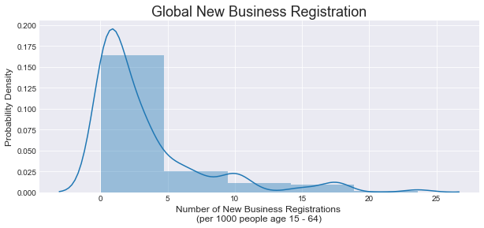

```python
sns.distplot(bus_env.bus_regi, bins = 5)

plt.title('Global New Business Registration', fontsize = 18)
plt.xlabel('Number of New Business Registrations \n(per 1000 people age 15 - 64)',\
           fontsize = 12)
plt.ylabel('Probability Density', fontsize = 12)

plt.show()
```

##### Commentary:

It appears that the number of new business registrations largely fall below 5 per 1000 people (age 15 - 64) across the countries, with the mean of 3.4.

```python
# top 25%
new_business.bus_regi.describe()
```

```
count    133.000000
mean       3.370714
std        4.388559
min        0.022000
25%        0.513000
50%        1.600000
75%        3.990000
max       23.600000
Name: bus_regi, dtype: float64
```

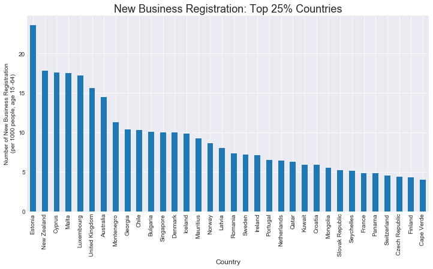

```python
new_business[new_business.bus_regi >= 3.99].bus_regi.plot(kind = 'bar', figsize = (12,6))

plt.title('New Business Registration: Top 25% Countries', fontsize = 18)
plt.xlabel('Country', fontsize = 12)
plt.ylabel('Number of New Business Registration\n (per 1000 people, age 15 -64)')

plt.show()
```

##### Commentary:

Estonia is ranked #1 with 23.6 new business registration per 1000 people between 15 and 64, followed by New Zealand, Cypus, Malta and Luxembourg.

```python
# finding other Asian countries here
new_business[new_business.bus_regi < 3.99]
```

| country | bus_regi | rank |
| --- | --- | --- |
| Peru | 3.7500 | 35.0 |
| Hungary | 3.7400 | 36.0 |
| North Macedonia | 3.6300 | 37.0 |
| Belize | 3.3900 | 38.0 |
| Belgium | 3.3700 | 39.0 |
| Lithuania | 3.3300 | 40.0 |
| Antigua and Barbuda | 3.3100 | 41.0 |
| Israel | 3.2700 | 42.0 |
| Russia | 3.2600 | 43.0 |
| Bahrain | 3.1100 | 44.0 |
| Slovenia | 3.0900 | 45.0 |
| Spain | 3.0700 | 46.0 |
| Armenia | 3.0500 | 47.0 |
| United Arab Emirates | 3.0400 | 48.0 |
| Italy | 2.9600 | 49.0 |
| South Korea | 2.8770 | 50.0 |
| Lesotho | 2.8300 | 51.0 |
| St. Lucia | 2.6900 | 52.0 |
| Costa Rica | 2.6000 | 53.0 |
| Grenada | 2.5200 | 54.0 |
| Malaysia | 2.3700 | 55.0 |
| Brunei | 2.3600 | 56.0 |
| Sao Tome and Principe | 2.3000 | 57.0 |
| Zimbabwe | 2.1300 | 58.0 |
| Colombia | 2.0200 | 59.0 |
| Kazakhstan | 2.0000 | 60.0 |
| Morocco | 1.9000 | 61.0 |
| Serbia | 1.8800 | 62.0 |
| Moldova | 1.8600 | 63.0 |
| Tunisia | 1.6800 | 64.0 |

[output cut: 69 more lines]

### `3-Q2.` Which countries have the most business friendly environment?

- Measured by: Degree of regulation and number of procedures to register a business.
- Variable: bus_ease, num_procedures
- Interpretation: the lower, the more business friendly

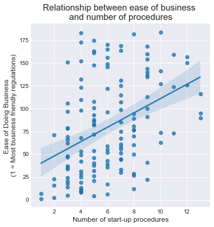

```python
# firstly identify relationship between the two variables

sns.lmplot(data = bus_env, x = 'num_procedures', y = 'bus_ease')

plt.title('Relationship between ease of business \nand number of procedures', fontsize = 15)
plt.xlabel('Number of start-up procedures', fontsize = 12)
plt.ylabel('Ease of Doing Business \n(1 = Most business friendly regulations)', fontsize = 12)

plt.show()
```

###### Commentary:

From the given data set, it appears that ease of doing business is positively correlated with the number of start-up procedures at a moderate level.

This means the lower number of start up procedures is likely to indicate the ease of doing business. However, the interpretation here is limited to the initial assumptinon, which requires more statitical studies or data to be validated.

```python
bus_env[['bus_ease','num_procedures']].corr() # moderately correlated
```

|  | bus_ease | num_procedures |
| --- | --- | --- |
| bus_ease | 1.000000 | 0.405948 |
| num_procedures | 0.405948 | 1.000000 |

```python
bus_env[['bus_ease','num_procedures']].sort_values(by = ['bus_ease'])
```

| country | bus_ease | num_procedures |
| --- | --- | --- |
| New Zealand | 1.0 | 1.0 |
| Singapore | 2.0 | 2.0 |
| Denmark | 4.0 | 5.0 |
| South Korea | 5.0 | 3.0 |
| United States | 6.0 | 6.0 |
| Georgia | 7.0 | 1.0 |
| United Kingdom | 8.0 | 4.0 |
| Norway | 9.0 | 4.0 |
| Sweden | 10.0 | 4.0 |
| Lithuania | 11.0 | 4.0 |
| Malaysia | 12.0 | 8.0 |
| Mauritius | 13.0 | 4.0 |
| Australia | 14.0 | 3.0 |
| United Arab Emirates | 16.0 | 2.0 |
| North Macedonia | 17.0 | 6.0 |
| Estonia | 18.0 | 3.0 |
| Latvia | 19.0 | 4.0 |
| Finland | 20.0 | 3.0 |
| Thailand | 21.0 | 5.0 |
| Germany | 22.0 | 9.0 |
| Canada | 23.0 | 2.0 |
| Ireland | 24.0 | 3.0 |
| Kazakhstan | 25.0 | 4.0 |
| Iceland | 26.0 | 5.0 |
| Austria | 27.0 | 8.0 |
| Russia | 28.0 | 4.0 |
| Japan | 29.0 | 8.0 |
| Spain | 30.0 | 7.0 |
| China | 31.0 | 4.0 |
| France | 32.0 | 5.0 |

[output cut: 105 more lines]

```python
bus_env[['bus_ease','num_procedures']].describe()
```

|  | bus_ease | num_procedures |
| --- | --- | --- |
| count | 135.000000 | 135.000000 |
| mean | 80.185185 | 6.088889 |
| std | 51.882069 | 2.675111 |
| min | 1.000000 | 1.000000 |
| 25% | 36.500000 | 4.000000 |
| 50% | 73.000000 | 6.000000 |
| 75% | 123.500000 | 8.000000 |
| max | 184.000000 | 13.000000 |

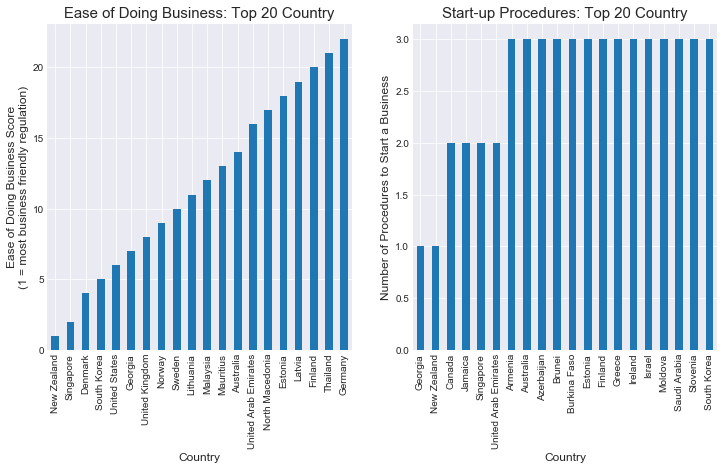

```python
fig, (ax1, ax2) = plt.subplots(1,2, figsize = (12,6))

bus_env.bus_ease.nsmallest(20).plot(kind = 'bar', ax = ax1)
bus_env.num_procedures.nsmallest(20).plot(kind = 'bar', ax = ax2)

ax1.set_title('Ease of Doing Business: Top 20 Country', fontsize = 15)
ax1.set_xlabel('Country', fontsize = 12)
ax1.set_ylabel('Ease of Doing Business Score\n(1 = most business friendly regulation)', fontsize = 12)

ax2.set_title('Start-up Procedures: Top 20 Country', fontsize = 15)
ax2.set_xlabel('Country', fontsize = 12)
ax2.set_ylabel('Number of Procedures to Start a Business', fontsize = 12)

plt.show()
```

### Findings

New Zealand has the most business friendly environment and it requires only 1 procedure to start a new business.

Singapore follows the next in business ease score, which is the higest level in Asia. South Korea also has an efficient environment for doing a business (scored 5, the second best in Asia) and fairly less number of procedures to start a business (3 procedures).

### `3-Q3.` In which countries it is the fastest to start a new business?

- Measured by: Time required to start a business (days) in 2019
- Variable: time_startup
- Interpretation: the lower, the faster

```python
bus_env.time_startup.describe()
```

```
count    135.000000
mean      15.360000
std       19.800668
min        0.500000
25%        6.000000
50%       10.000000
75%       17.750000
max      173.000000
Name: time_startup, dtype: float64
```

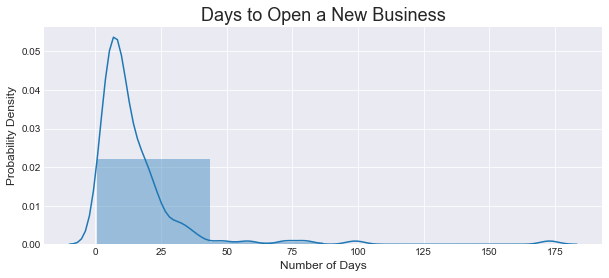

```python
plt.style.use('seaborn-darkgrid')
plt.figure(figsize = (10, 4))

sns.distplot(bus_env.time_startup, bins = 4)

plt.title('Days to Open a New Business', fontsize = 18)
plt.xlabel('Number of Days', fontsize = 12)
plt.ylabel('Probability Density', fontsize = 12)

plt.show()
```

##### Commentary:

More than 75% of the listed countries require less than 20 days to open a new business, where top 25% take less than 6 days, and an outlier country is seen with nearly 173 days for a new opening.

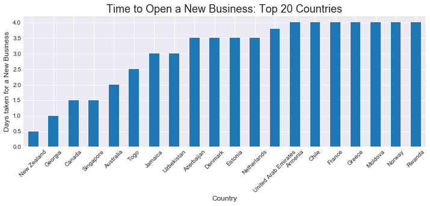

```python
plt.figure(figsize = (12, 4))
bus_env.time_startup.nsmallest(20).plot(kind = 'bar')

plt.title('Time to Open a New Business: Top 20 Countries', fontsize = 18)
plt.xlabel('Country', fontsize = 12)
plt.xticks(rotation = 45)
plt.ylabel('Days taken for a New Business', fontsize = 12)

plt.show()
```

```python
bus_env.time_startup.loc['South Korea']
```

```
8.0
```

```python
bus_env.time_startup.loc['Malaysia']
```

```
17.5
```

##### Commentary:

Of 135 listed countries, in more than 50% of the countries, it takes less than 10 days to open a new business.

Given the efficiency of starting a business (only 1 procedure to follow), New Zealand records 0.5 day to start a new busines.

Although the earlier findings show that Malaysia has a relatively good business environment in Asia, but in fact, it takes 17.5 days to start a new business.

### `3-Q4.` Study factors for business registration.

Have all factors like ease in doing business, low number of startup procedures and fast establishment of a new business actually impacted the number of new business registration?

Any macro environmental effects?

#### New business related

- bus_regi: New registration per 1000 people, age 15 - 64) in 2018
- bus_ease: Ease of doing business index (1 = most business friendly regulations) in 2019
- time_startup: Time required to start a business (days) in 2019
- num_procedures: Start-up procedures to register a business (number) in 2019 (located in the last column)

#### New business related factors: Correlation to number of business registration

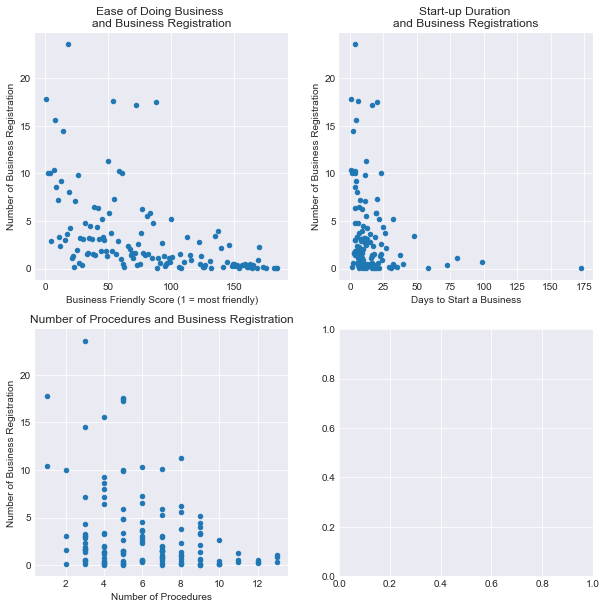

```python
fig, axes = plt.subplots(2,2, figsize = (10, 10))

bus_env.plot(kind = 'scatter', x = 'bus_ease', y = 'bus_regi', ax = axes[0,0])
bus_env.plot(kind = 'scatter', x = 'time_startup', y = 'bus_regi', ax = axes[0,1])
bus_env.plot(kind = 'scatter', x = 'num_procedures', y = 'bus_regi', ax = axes[1,0])

axes[0,0].set_title('Ease of Doing Business \nand Business Registration', fontsize = 12)
axes[0,1].set_title('Start-up Duration \nand Business Registrations', fontsize = 12)
axes[1,0].set_title('Number of Procedures and Business Registration', fontsize = 12)

axes[0,0].set_xlabel('Business Friendly Score (1 = most friendly)', fontsize = 10)
axes[0,1].set_xlabel('Days to Start a Business', fontsize = 10)
axes[1,0].set_xlabel('Number of Procedures', fontsize = 10)

axes[0,0].set_ylabel('Number of Business Registration', fontsize = 10)
axes[0,1].set_ylabel('Number of Business Registration', fontsize = 10)
axes[1,0].set_ylabel('Number of Business Registration', fontsize = 10)

plt.show()
```

```python
bus_env.corr().bus_regi
```

```
bus_regi          1.000000
bus_ease         -0.497517
time_startup     -0.195286
foreign_invest    0.147759
income            0.516580
life_exp          0.463916
pop_density       0.154825
num_procedures   -0.309502
Name: bus_regi, dtype: float64
```

##### Commentary:

Note | the lower the values of 'bus_ease', 'time_startup', 'num_procedures', the more likely business friendly environment.

Whilst it is difficult yet to jump into the conclusion without any further statistical testing, the first impression tells that ease of doing business and low number of procedures are likely to be one of the factors in starting a business. However, time that it takes to start up a business does not seemingly affect the decision on opening a new business.

#### Macro factors: Correlation to number of business registration

```python
bus_env.head(3)
```

| country | bus_regi | bus_ease | time_startup | foreign_invest | income | life_exp | pop_density | num_procedures |
| --- | --- | --- | --- | --- | --- | --- | --- | --- |
| Afghanistan | 0.212 | 173.0 | 8.5 | 0.00617 | 1760.0 | 64.1 | 58.3 | 4.0 |
| Albania | 1.520 | 82.0 | 4.5 | 0.07970 | 12700.0 | 78.5 | 105.0 | 5.0 |
| Algeria | 0.353 | 157.0 | 18.0 | 0.00867 | 14000.0 | 78.1 | 18.1 | 12.0 |

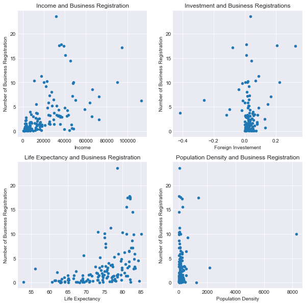

```python
fig, axes = plt.subplots(2,2, figsize = (10, 10))

bus_env.plot(kind = 'scatter', x = 'income', y = 'bus_regi', ax = axes[0,0])
bus_env.plot(kind = 'scatter', x = 'foreign_invest', y = 'bus_regi', ax = axes[0,1])
bus_env.plot(kind = 'scatter', x = 'life_exp', y = 'bus_regi', ax = axes[1,0])
bus_env.plot(kind = 'scatter', x = 'pop_density', y = 'bus_regi', ax = axes[1,1])

axes[0,0].set_title('Income and Business Registration', fontsize = 12)
axes[0,1].set_title('Investment and Business Registrations', fontsize = 12)
axes[1,0].set_title('Life Expectancy and Business Registration', fontsize = 12)
axes[1,1].set_title('Population Density and Business Registration', fontsize = 12)

axes[0,0].set_xlabel('Income', fontsize = 10)
axes[0,1].set_xlabel('Foreign Investement', fontsize = 10)
axes[1,0].set_xlabel('Life Expectancy', fontsize = 10)
axes[1,1].set_xlabel('Population Density', fontsize = 10)

axes[0,0].set_ylabel('Number of Business Registration', fontsize = 10)
axes[0,1].set_ylabel('Number of Business Registration', fontsize = 10)
axes[1,0].set_ylabel('Number of Business Registration', fontsize = 10)
axes[1,1].set_ylabel('Number of Business Registration', fontsize = 10)

plt.show()
```

##### Commentary:

Again, whilst it is difficult to draw a conclusion yet without any further testing, it appears that income and life expectancy is positively but moderately related to opening a new busines (represented by number of business registration). However, level of foreign direct investement inflow and population density are less likely to be factors to start up.

## 4. Conclusions

### Finding:

In this project, I would like to figure business friendly countries in Asia. Also, I would like to take a brief lookt at potential factors leading to new business registration.

> `2.` New Zealand is known to have the easiest (friendly) business environment, with only 1 procedure to take to a new business establishment. In Asia Singapore follows the second, which is the higest level in Asia. South Korea also has an efficient environment for doing and starting a business, the second best in Asia, follwed by Malaysia.

> `4.` The first impression tells that ease of doing business and low number of procedures are likely to be factors in starting a business. However, time that it takes to start up a business does not seemingly affect the decision of opening a new business.

> `5.` It appears that income and life expectancy is positively but moderately related to registering for a new busines. However, level of foreign direct investement inflow and population density are less likely to be factors to start up.

This study has limitations. For the simplicity purpose, the data was derived from a certain year position only. Also, correlation and explanatory analysis was performed just at the introductory level. Last, data for the key variable (business registration per 1000 people) is limited with many missing data toward the recent years that I was interested to study and cost of start_up data was dropped due to the same reason of missing dataset.

Therefore, for better insights, more comprehensive data set should be obtained, and better statistical testing should be performed.